# Instructor and trainee involvement

Erin Becker

May 18, 2016

## Instructor and trainee involvement in workshops

This analysis is meant to answer questions about the extent of the non-teaching instructor and the non-certified trainee issues. Questions to be answered include:

1. What percent of fully certified instructors haven’t taught?
   - Overall
   - Only those > 1 year past training
2. What percent of one-time instructors have only taught at their home institution?
3. What percent of trainees haven’t finished checkout within 90 days of training?
   - Including online trainees
   - Excluding online trainees

Data was collected from AMY database (instructor completion) and Google sheet (trainee completion) by `Greg Wilson` on `5/17/16`. De-identified data can be accessed [here](https://github.com/datacarpentry/metrics/tree/master/instructor_data).

*Note: This data can not answer Question #2.*

Definitions:  
*Trainee* - person who has gone through instructor training but may not have completed checkout.  
*Instructor* - person who has gone through both instructor training and checkout.

## Trainee completion rate

Looking only at training sessions from at least 90 days ago:  
- overall completion **54.73%**  
- in person completion **56.21%**  
- online completion **51.35%**. (Two events, 63% and 31%).

Most (10/14) in person events have >65% completion rate. Some (Arlington, OK, Melbourne, Florida) much lower.

**Takeaway:** Overall, online sessions didn’t have a noticably lower completion rate than in-person sessions, but this appears to be due to a few in-person sessions have very low completion rates.

Some other events do not look on track to meeting normal completion rates (e.g. UCDavis - 84 days, 39%; UW - 68 days, 14%). More follow-up with these participants likely needed.

*Wonder whether these abnormal rates are due to issues with local community, issues with how training session went, or some other factor.*

Summary of completion rates per event:

```
##    Min. 1st Qu.  Median    Mean 3rd Qu.    Max.
##   22.22   38.00   70.72   66.73   89.28  100.00
```

Note that mean completion rate for individual events is **not** the same as mean overall completion rate, as the number of participants per event varies.

## Instructor teaching rate

What percent of instructors trained over a year ago haven’t yet taught?  
Trained over one year ago: **378**  
Of which, haven’t taught: **70**  
This is **18.52%**.

What percent of total instructors haven’t taught?  
Total trained: **673**  
Haven’t taught: **222**  
This is **32.99%**.

What percent of instructors trained within the past year haven’t yet taught?  
Trained within last year: **295**  
Of which, haven’t taught: **152**  
This is **51.53%**. (But many of these may have been trained very recently.)

What is the distribution of time to first teaching?

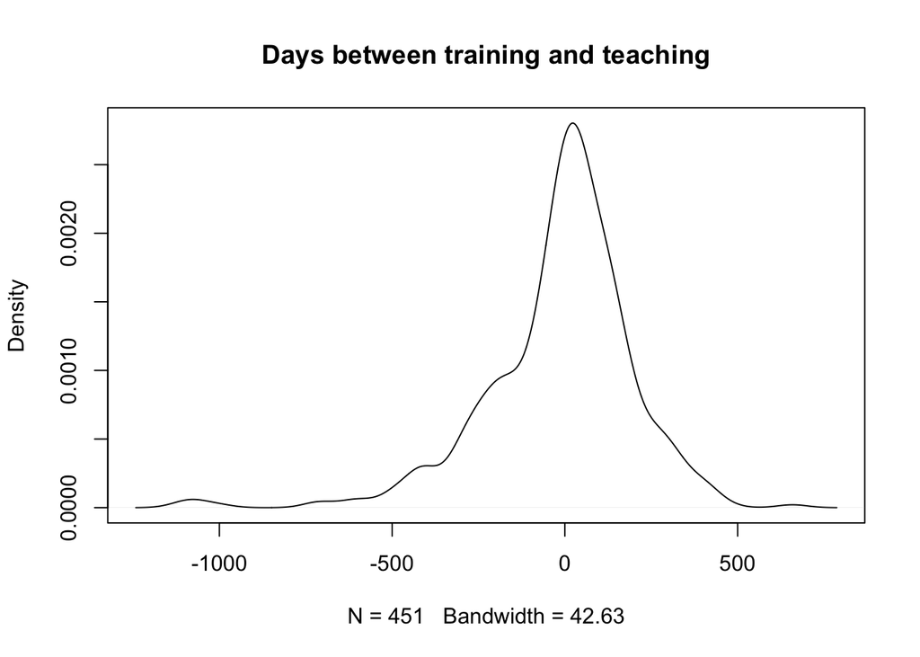

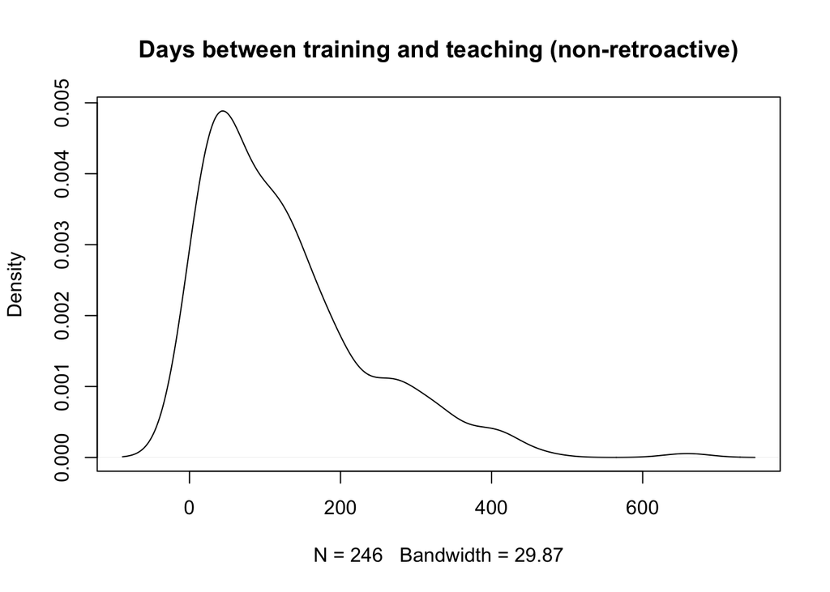

Summary of time to teach first workshop (non-retroactive):

```
##    Min. 1st Qu.  Median    Mean 3rd Qu.    Max.
##     1.0    42.0    98.0   124.6   175.8   659.0
```

Are recently trained instructors on track to meet normal teaching rates?  
Overall, half of instructors teach w/in `98` days.

Trained between 95-120 days ago: **71**  
Of which, haven’t taught: **33**  
This is **46.48%**.

Recent batch of trainees appear to be on track.

## Conclusions

Online training sessions do **not** appear to have lower completion rates than in-person sessions. Completion rates are quite variable between training sessions. This may indicate greater follow-up needed. Overall completion rates ~55%.